# 10 Ordinal and Ranked Responses

## Properties of the latent class logit model

Among the properties of the latent class logit, two are of interest.

The first one can be illustrated by means of the odds-ratio of two alternatives, say $i$ and $j$:
$$\frac{P_{ni}}{P_{nj}} = \frac{\sum_q^Q p_q\frac{e^{V_{niq}}}{\sum_k e^{V_{nkq}}}}{\sum_q^Q p_q\frac{e^{V_{njq}}}{\sum_k e^{V_{nkq}}}}$$

When $Q=1$ the model collapses to the multinomial logit model and proportional substitution patterns. When $Q\ge3$, on the other hand, the denominator of the logit probabilities is inside the summation for the classes, and does not vanish:
$$\frac{P_{ni}}{P_{nj}} = \frac{p_1\frac{e^{V_{ni1}}}{\sum_k e^{V_{nk1}}} + p_2\frac{e^{V_{ni2}}}{\sum_k e^{V_{nk1}}} + p_3\frac{e^{V_{ni3}}}{\sum_k e^{V_{nk3}}}}{p_1\frac{e^{V_{nj1}}}{\sum_k e^{V_{nk1}}} + p_2\frac{e^{V_{nj2}}}{\sum_k e^{V_{nk1}}}+ p_3\frac{e^{V_{ni3}}}{\sum_k e^{V_{nk3}}}}$$

Therefore, the latent class logit model does not display independence from irrelevant alterantives.

Secondly, latent class logit models with higher number of classes do *not* nest into each other. The reason for this is that the parameters that define the probability of belonging to a class are contingent on the number of classes. Therefore, reducing the number of classes, say from $Q=3$ to $Q=2$, is not equivalent to restricting some parameters to be zero. As a consequence, latent class models cannot be compared by means of the likelihood ratio test. Further, since the log-likelihood always improves with the addition of classes, it is not possible to compare the likelihood directly.

Instead, criteria that account for the size of the models are used. Roeder et al. [-@Roeder1999modeling] suggest using the Bayesian Information Criterion:
$$BIC = k\ln(n)-2\hat{l}$$
where $k$ is the number of parameters in the model, $n$ is the sample size, and $\hat{l}$ is the maximized value of the likelihood of the model.

Shen [-@Shen2009latent] suggests using Akaike’s Information Criterion:
$$AIC = 2k-2\hat{l}$$
or Consistent Akaike’s Information Criterion:
$$CAIC = k[ln(n)+1]-2\hat{l}$$
The three criteria above use the likelihood of the model and apply a penalty based on the size of the model and possibly the size of the sample. Since the negative of the likelihood is used in the calculations, minimizing an information criteria is an indicator of goodness-of-fit.

In particular, when using $AIC$, the following decision rule could be followed. Suppose that there are candidate models with $q=1, 2, \cdots,Q$ latent classes. Calculate the $AIC$ for each model, such that there are $AIC_{q=1}, AIC_{q=2},\cdots, AIC_{q=Q}$. Denote the minimum $AIC$ as $AIC_{min}$. The *relative likelihood* is defined as:
$$RL = e^{\frac{AIC_{min}-AIC_q}{2}}$$
The interpretation of the relative likelihood is as being proportional to the probability that the model with $q$ classes minimizes the estimated information loss.

## Empirical example

Here we revisit the empirical example. To estimate latent class models we use the package `gmnl`. This package uses a similar syntax for specifying multi-part formulas as `mlogit`. In particular, the parts of a formula are:
$$\begin{array}{cr}
choice & \sim& \text{alternative attributes with generic coefficients } |\\
&&\text{individual attributes }|\\
&&\text{alternative attributes with specific coefficients }|\\
&&\text{variables for random coefficients }|\\
&&\text{variables for latent class model }\\
\end{array}$$

We proceed to estimate latent class models as follows, with $Q=2$ and $Q=3$ (i.e., two and three latent classes):

```r
lc2 <- gmnl(choice ~ cost + risk | 0 | 0 | 0 | 1,
           data = RT,
           model = 'lc',
           Q = 2,
           panel = TRUE,
           method = "bhhh")
```

```
Estimating LC model
```

```r
#summary(lc2)
lc3 <- gmnl(choice ~ cost + risk | 0 | 0 | 0 | 1,
           data = RT,
           model = 'lc',
           Q = 3,
           panel = TRUE,
           method = "bhhh")
```

```
Estimating LC model
```

```r
#summary(lc3)
```

The results of these models are summarized in the table below.

```r
# Estimate a constants only model to calculate McFadden's _adjusted_ rho2
names(mnl.rt0$coefficients) <- c("class.1.cost", "class.1.risk")
mnl0.summary <- rownames_to_column(data.frame(summary(mnl.rt0)$CoefTable), "Variable") %>%
  transmute(Variable, Estimate, pval = `Pr...z..`)
lc2.summary <- rownames_to_column(data.frame(summary(lc2)$CoefTable), "Variable") %>%
  transmute(Variable, Estimate, pval = `Pr...z..`)
lc3.summary <- rownames_to_column(data.frame(summary(lc3)$CoefTable), "Variable") %>%
  transmute(Variable, Estimate, pval = `Pr...z..`)
df <- full_join(mnl0.summary, lc2.summary, by = "Variable") %>%
  full_join(lc3.summary, by = "Variable")
kable(df,
      "html",
      digits = 4,
      col.names = c("Variable",
                    "Estimate",
                    "p-value",
                    "Estimate",
                    "p-value",
                    "Estimate",
                    "p-value"),
      caption = "Base models: multinomial logit (MNL), latent class Q = 2 (LC2), latent class Q = 3 (LC3)") %>%
  kable_styling() %>%
  add_header_above(c(" " = 1, "MNL" = 2, "LC2" = 2, "LC3" = 2)) %>%
  footnote(general = c(paste0("Log-Likelihood: MNL = ", round(mnl.rt0$logLik[1], digits = 3),
                            "; Latent Class (Q=2) = ", round(lc2$logLik$maximum, digits = 3),
                            "; Latent Class (Q=2) = ", round(lc3$logLik$maximum, digits = 3))))
```

[output not shown]

Base models: multinomial logit (MNL), latent class Q = 2 (LC2), latent class Q = 3 (LC3)

| Variable | MNL Estimate | MNL p-value | LC2 Estimate | LC2 p-value | LC3 Estimate | LC3 p-value |
| --- | --- | --- | --- | --- | --- | --- |
| class.1.cost | -0.0140 | 0 | -0.1256 | 0.0167 | -0.1151 | 0.0202 |
| class.1.risk | -0.2531 | 0 | -0.6347 | 0.1540 | -0.0365 | 0.9260 |
| class.2.cost | NA | NA | 0.0026 | 0.3359 | -0.0678 | 0.0044 |
| class.2.risk | NA | NA | -0.3725 | 0.0000 | -2.4147 | 0.0026 |
| (class)2 | NA | NA | 0.4207 | 0.0115 | -0.0886 | 0.7050 |
| class.3.cost | NA | NA | NA | NA | 0.0097 | 0.0048 |
| class.3.risk | NA | NA | NA | NA | -0.2766 | 0.0633 |
| (class)3 | NA | NA | NA | NA | 0.0787 | 0.7126 |

Note:  
Log-Likelihood: MNL = -335.213; Latent Class (Q=2) = -310.677; Latent Class (Q=2) = -299.196

Notice that model LC3, despite improving the likelihood, returns non-significant parameters for the latent class model. For this reason, we compare only the multinomila logit model and LC2.

The $AIC$ of the base multinomial logit model is:

```r
2 * length(coef(mnl.rt0)) - 2 * mnl.rt0$logLik
```

```
'log Lik.' 674.426 (df=2)
```

The $AIC$ of model LC2 is:

```r
2 * length(coef(lc2)) - 2 * lc2$logLik$maximum
```

```
[1] 631.3531
```

The minimum $AIC$ is for the latent class model. If we calculate the relative likelihood:

```r
as.numeric(exp(((2 * length(coef(lc2)) - 2 * lc2$logLik$maximum) - (2 * length(coef(mnl.rt0)) - 2 * mnl.rt0$logLik))/2))
```

```
[1] 4.434555e-10
```

Therefore, the standard multinomial logit model is less than $0.001$ times probable as the latent class model with $Q=2$ to minimize the information loss.

Notice that in the latent class model, the coefficient for risk in class 1 is not significant, whereas the coefficient for cost in class 2 is not significant. This suggests that class 1 is more cost-averse and class 2 more risk-averse.

To calculate the shares of the latent classes in the population, we can write the latent class model as follows:
$$p_2 = \frac{e^{0.4207}}{1 + e^{0.4207}}$$
and:
$$p_1 = 1 - p_2$$

Therefore, the share for class 1 is:

```r
as.numeric(1 - exp(coef(lc2)["(class)2"])/(1 + exp(coef(lc2)["(class)2"])))
```

```
[1] 0.3963601
```

and the share for class 2 is:

```r
as.numeric(exp(coef(lc2)["(class)2"])/(1 + exp(coef(lc2)["(class)2"])))
```

```
[1] 0.6036399
```

## Adding individual-level attributes

A question when doing this kind of analysis is, to what extent can the inclusion of individual-level attributes capture the variations in taste.

Here, we revisit the models after adding covariates. There are two multinomial logit models. In one, we introduce the same covariate to all but one utility function (MNL-COV), and in a second model the covariate is used to expand the coefficients of the alternative-level attributes as follows:
$$V_{ni} = (b_{cost} + b_{cost:dwage}dwage_n)cost_i + (b_{risk} + b_{risk:dwage}dwage_n)risk_i$$

These models are estimated next:

```r
mnl.cov <- mlogit(choice ~ cost + risk | dwage + 0,
                data = RT)
#summary(mnl.cov)
mnl.exp <- mlogit(choice ~ cost + cost:dwage +
                   risk + risk:dwage | 0,
                data = RT)
#summary(mnl.exp)
```

The models are summarized next:

```r
mnl.cov.summary <- rownames_to_column(data.frame(summary(mnl.cov)$CoefTable), "Variable") %>%
  transmute(Variable, Estimate, pval = `Pr...z..`)
mnl.exp.summary <- rownames_to_column(data.frame(summary(mnl.exp)$CoefTable), "Variable") %>%
  transmute(Variable, Estimate, pval = `Pr...z..`)
df <- full_join(mnl.cov.summary, mnl.exp.summary, by = "Variable")
kable(df,
      "html",
      digits = 4,
      col.names = c("Variable",
                    "Estimate",
                    "p-value",
                    "Estimate",
                    "p-value"),
      caption = "Models: multinomial logit with covariates (MNL-COV) and multinomial logit with expanded coefficients (MNL-EXP)") %>%
  kable_styling() %>%
  add_header_above(c(" " = 1, "MNL-COV" = 2, "MNL-EXP" = 2)) %>%
  footnote(general = c(paste0("Log-Likelihood: MNL-COV = ", round(mnl.cov$logLik[1], digits = 3),
                            "; MNL-EXP = ", round(mnl.exp$logLik[1], digits = 3))))
```

[output not shown]

Models: multinomial logit with covariates (MNL-COV) and multinomial logit with expanded coefficients (MNL-EXP)

| Variable | MNL-COV Estimate | MNL-COV p-value | MNL-EXP Estimate | MNL-EXP p-value |
| --- | --- | --- | --- | --- |
| cost | -0.0117 | 0.0000 | -0.0157 | 0.0000 |
| risk | -0.1662 | 0.0193 | -0.1429 | 0.0249 |
| dwage:WaterTaxi | 0.0592 | 0.3608 | NA | NA |
| dwage:Ferry | 0.0597 | 0.3473 | NA | NA |
| dwage:Hovercraft | 0.0445 | 0.4846 | NA | NA |
| cost:dwage | NA | NA | 0.0001 | 0.0006 |
| risk:dwage | NA | NA | -0.0042 | 0.0245 |

Note:  
Log-Likelihood: MNL-COV = -323.807; MNL-EXP = -329.728

The $AIC$ of MNL-COV is:

```r
as.numeric(2 * length(coef(mnl.cov)) - 2 * mnl.cov$logLik)
```

```
[1] 657.6149
```

and the $AIC$ of MNL-EXP is:

```r
as.numeric(2 * length(coef(mnl.exp)) - 2 * mnl.exp$logLik)
```

```
[1] 667.4561
```

The minimum $AIC$ is still for latent class model LC2. If we calculate the relative likelihood with respect to the best performing multinomial logit model:

```r
as.numeric(exp(((2 * length(coef(lc2)) - 2 * lc2$logLik$maximum) - (2 * length(coef(mnl.cov)) - 2 * mnl.cov$logLik))/2))
```

```
[1] 1.983059e-06
```

Clearly, latent class model LC2 is still the best candidate for fit.

## Adding variables to the latent class selection model

The latent class model can accommodate individual level attributes in the class selection model. The model thus becomes:
$$p_q = \frac{e^{\gamma'_q x_i}}{\sum_{z=1}^Qe^{\gamma'_z x_i}}$$
where now $\gamma_q$ is a vector of size $1 \times h$ and $x_1$ is a vector of $h$ individual-level attributes. As before, $\gamma_1 = 0$.

To estimate a model with variables in the selection model, the fifth part of the formula is used, as shown next (call this model LC2-COV):

```r
lc2.cov <- gmnl(choice ~ cost + risk | 0 | 0 | 0 | dwage,
           data = RT,
           model = 'lc',
           Q = 2,
           panel = TRUE,
           method = "nm",
           iterlim = 1200)
```

```
Estimating LC model
```

```r
summary(lc2.cov)
```

```
Model estimated on: Sun Mar 31 7:29:37 PM 2019

Call:
gmnl(formula = choice ~ cost + risk | 0 | 0 | 0 | dwage, data = RT,
    model = "lc", Q = 2, panel = TRUE, method = "nm", iterlim = 1200)

Frequencies of categories:

Helicopter  WaterTaxi      Ferry Hovercraft
  0.003125   0.403125   0.459375   0.134375

The estimation took: 0h:0m:4s

Coefficients:
               Estimate Std. Error z-value  Pr(>|z|)
class.1.cost -0.1159165  0.0333901 -3.4716 0.0005174 ***
class.1.risk  0.0861966  0.1056785  0.8156 0.4147008
class.2.cost  0.0018230  0.0031749  0.5742 0.5658431
class.2.risk -0.6166901  0.0994760 -6.1994 5.668e-10 ***
(class)2     -0.3362670  0.2237047 -1.5032 0.1327943
dwage:class2  0.0317098  0.0080091  3.9592 7.519e-05 ***
---
Signif. codes:  0 ‘***’ 0.001 ‘**’ 0.01 ‘*’ 0.05 ‘.’ 0.1 ‘ ’ 1

Optimization of log-likelihood by Nelder-Mead maximization
Log Likelihood: -302.22
Number of observations: 320
Number of iterations: 1149
Exit of MLE: successful convergence
```

The $AIC$ of this model is:

```r
as.numeric(2 * length(coef(lc2.cov)) - 2 * lc2.cov$logLik$maximum)
```

```
[1] 616.4306
```

which improves on the $AIC$ of the LC2 model:

```r
as.numeric(2 * length(coef(lc2)) - 2 * lc2$logLik$maximum)
```

```
[1] 631.3531
```

The relative likelihood is now:

```r
as.numeric(exp(((2 * length(coef(lc2.cov)) - 2 * lc2.cov$logLik$maximum) - (2 * length(coef(lc2)) - 2 * lc2$logLik$maximum))/2))
```

```
[1] 0.0005749284
```

Which clearly indicates the improved performance of the model LC2-COV.

The model still points at two classes of decision-makers, cost-averse and risk-averse. However, the probability of membership in those classes now changes as a function of declared wage. The following figure explores the shares of the classes by levels of wage:

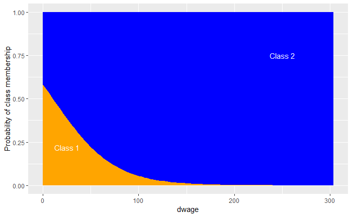

```r
#Create a dataframe for plotting:
df <- data.frame(dwage = seq(min(RT$dwage), to = max(RT$dwage), by = (max(RT$dwage) - min(RT$dwage))/100))
# Use the class selection model to calculate the membership probabilities
df <- df %>% mutate(p_1 = 1 - exp(coef(lc2.cov)["(class)2"] + coef(lc2.cov)["dwage:class2"] * dwage)/(1 + exp(coef(lc2.cov)["(class)2"] + coef(lc2.cov)["dwage:class2"] * dwage)),
                    p_2 = exp(coef(lc2.cov)["(class)2"] + coef(lc2.cov)["dwage:class2"] * dwage)/(1 + exp(coef(lc2.cov)["(class)2"] + coef(lc2.cov)["dwage:class2"] * dwage)))
# Plot
ggplot(df, aes(x = dwage)) +
  geom_ribbon(aes(ymin = 0, ymax = 1), fill = "blue") +
  geom_ribbon(aes(ymin = 0, ymax = p_1), fill = "orange") +
  ylab("Probability of class membership") +
  annotate("text", x = 25, y = 0.22, label = "Class 1", color = "white") +
  annotate("text", x = 250, y = 0.75, label = "Class 2", color = "white")
```

## Exercise

Load the following dataset (used in this chapter):

```r
data("RiskyTransport", package = "mlogit")
```

Select individuals who had access to all four modes of transportation:

```r
all_available <- RiskyTransport %>% group_by(chid) %>% summarise(no_rows = length(chid)) %>% filter(no_rows == 4) %>% select(chid)
RT <- inner_join(RiskyTransport, all_available, by = "chid") %>% drop_na()
```

1. Estimate a mixed logit model using the Risky Transportation dataset used in this chapter. Compare the mixed logit model and the latent class logit models. Which one would you select? Discuss.

Load the following dataset from the `AER` package:

```r
data("TravelMode", package = "AER")
```

2. Estimate a latent class logit model. Justify your modelling decisions, including the number of classes to use and the use of covariates.